# Assignment 2 : AI-ML Morning Batch

## Submitted by : Ashutosh Bandooni

### Step 1 : Import needed libraries

```python
import pandas as pd
import numpy as np
import seaborn as sns
import matplotlib.pyplot as plt
```

### Step 2 : Import the car_crashes dataset

```python
df = sns.load_dataset('car_crashes')
```

```python
df.head()
```

|  | total | speeding | alcohol | not_distracted | no_previous | ins_premium | ins_losses | abbrev |
| --- | --- | --- | --- | --- | --- | --- | --- | --- |
| 0 | 18.8 | 7.332 | 5.640 | 18.048 | 15.040 | 784.55 | 145.08 | AL |
| 1 | 18.1 | 7.421 | 4.525 | 16.290 | 17.014 | 1053.48 | 133.93 | AK |
| 2 | 18.6 | 6.510 | 5.208 | 15.624 | 17.856 | 899.47 | 110.35 | AZ |
| 3 | 22.4 | 4.032 | 5.824 | 21.056 | 21.280 | 827.34 | 142.39 | AR |
| 4 | 12.0 | 4.200 | 3.360 | 10.920 | 10.680 | 878.41 | 165.63 | CA |

```python
df.describe()
```

|  | total | speeding | alcohol | not_distracted | no_previous | ins_premium | ins_losses |
| --- | --- | --- | --- | --- | --- | --- | --- |
| count | 51.000000 | 51.000000 | 51.000000 | 51.000000 | 51.000000 | 51.000000 | 51.000000 |
| mean | 15.790196 | 4.998196 | 4.886784 | 13.573176 | 14.004882 | 886.957647 | 134.493137 |
| std | 4.122002 | 2.017747 | 1.729133 | 4.508977 | 3.764672 | 178.296285 | 24.835922 |
| min | 5.900000 | 1.792000 | 1.593000 | 1.760000 | 5.900000 | 641.960000 | 82.750000 |
| 25% | 12.750000 | 3.766500 | 3.894000 | 10.478000 | 11.348000 | 768.430000 | 114.645000 |
| 50% | 15.600000 | 4.608000 | 4.554000 | 13.857000 | 13.775000 | 858.970000 | 136.050000 |
| 75% | 18.500000 | 6.439000 | 5.604000 | 16.140000 | 16.755000 | 1007.945000 | 151.870000 |
| max | 23.900000 | 9.450000 | 10.038000 | 23.661000 | 21.280000 | 1301.520000 | 194.780000 |

```python
df.duplicated().any()
```

```
False
```

Its established that we have data for all US states with no duplicated values. Now, we can move on to the visualisations.

### Step 3 : Visualising the data

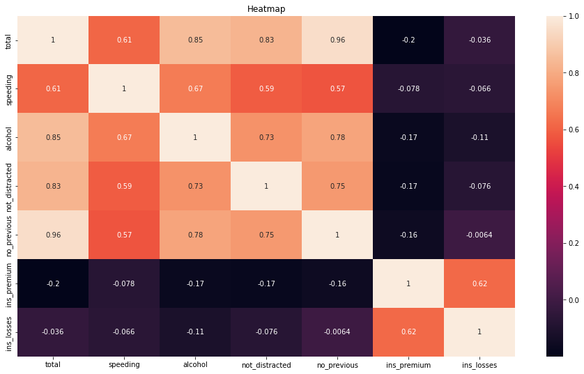

```python
plt.figure(figsize=(16,9))
plt.title("Heatmap")
sns.heatmap(data=df.corr(),annot=True)
```

It is inferred that the number of drivers per billion miles are highly correlated with cases pertaining to percentage of drivers either impaired with alcohol(0.85), or having no previous cases of fatal accidents(0.96).

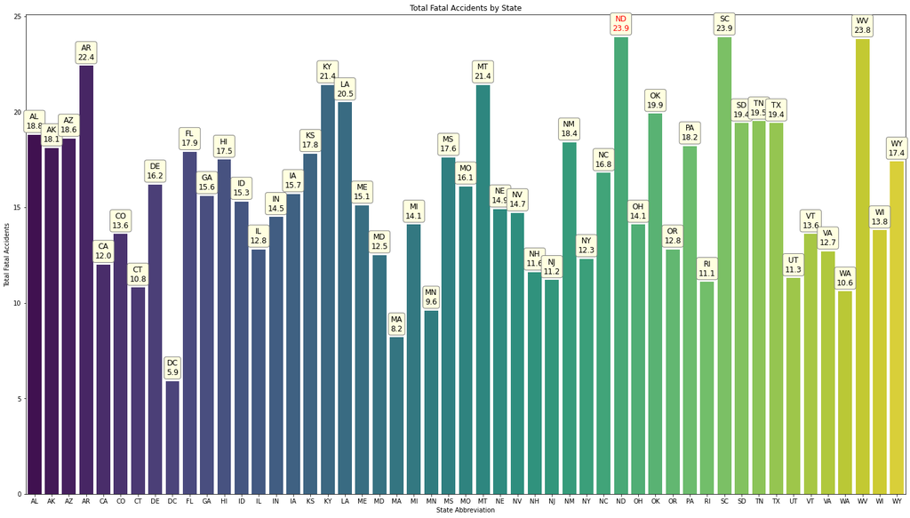

```python
plt.figure(figsize=(25,14))
top_state = df.loc[df['total'].idxmax()]
sns.barplot(x="abbrev", y="total", data=df, palette="viridis")
for index, row in df.iterrows():
    if row["abbrev"] == top_state["abbrev"]:
        plt.annotate(f'{row["abbrev"]}\n{row["total"]}',
                    xy=(index, row["total"]),
                    xytext=(0, 10),
                    textcoords='offset points',
                    ha='center',
                    fontsize=12,
                    color='red',
                    bbox=dict(boxstyle='round,pad=0.3', edgecolor='gray', facecolor='lightyellow'))
    else:
        plt.annotate(f'{row["abbrev"]}\n{row["total"]}',
                    xy=(index, row["total"]),
                    xytext=(0, 10),
                    textcoords='offset points',
                    ha='center',
                    fontsize=12,
                    color='black',
                    bbox=dict(boxstyle='round,pad=0.3', edgecolor='gray', facecolor='lightyellow'))
plt.xlabel("State Abbreviation")
plt.ylabel("Total Fatal Accidents")
plt.title("Total Fatal Accidents by State")
```

As we see in this barchart, the states of North Dakota and South Carolina, have the highest fatal accidents, with 23.9 accidents per billion miles

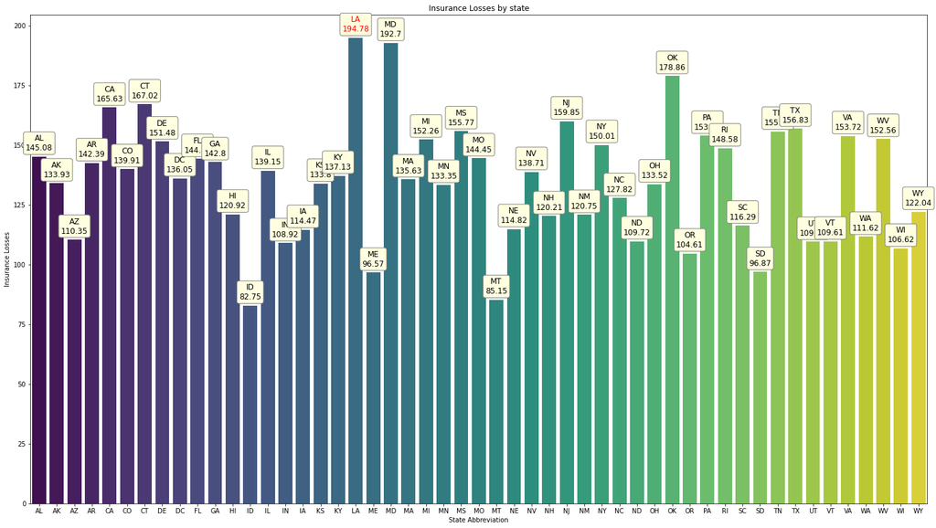

```python
plt.figure(figsize=(25,14))
top_state = df.loc[df['ins_losses'].idxmax()]
sns.barplot(x="abbrev", y="ins_losses", data=df, palette="viridis")
for index, row in df.iterrows():
    if row["abbrev"] == top_state["abbrev"]:
        plt.annotate(f'{row["abbrev"]}\n{row["ins_losses"]}',
                    xy=(index, row["ins_losses"]),
                    xytext=(0, 10),
                    textcoords='offset points',
                    ha='center',
                    fontsize=12,
                    color='red',
                    bbox=dict(boxstyle='round,pad=0.3', edgecolor='gray', facecolor='lightyellow'))
    else:
        plt.annotate(f'{row["abbrev"]}\n{row["ins_losses"]}',
                    xy=(index, row["ins_losses"]),
                    xytext=(0, 10),
                    textcoords='offset points',
                    ha='center',
                    fontsize=12,
                    color='black',
                    bbox=dict(boxstyle='round,pad=0.3', edgecolor='gray', facecolor='lightyellow'))
plt.xlabel("State Abbreviation")
plt.ylabel("Insurance Losses")
plt.title("Insurance Losses by state")
```

```
10.038
```

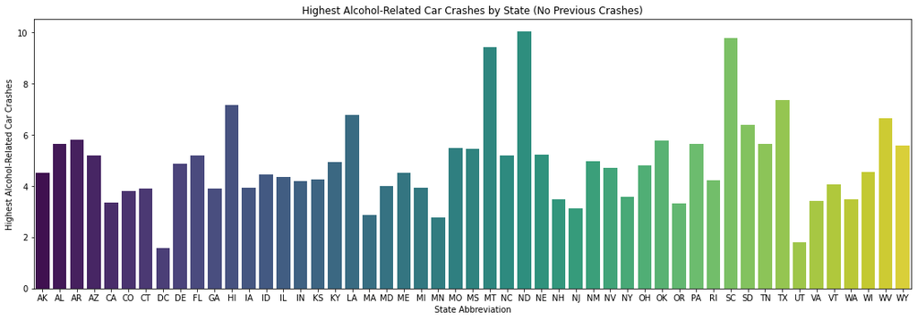

```python
max_alcohol_state = df.groupby('abbrev')['alcohol'].idxmax()
filtered_data = df.loc[max_alcohol_state]
max_value = df.loc[df['alcohol'].idxmax()]['alcohol']

plt.figure(figsize=(19, 6))

sns.barplot(x='abbrev', y='alcohol',data=filtered_data, palette='viridis')


plt.xlabel("State Abbreviation")
plt.ylabel("Highest Alcohol-Related Car Crashes")
plt.title("Highest Alcohol-Related Car Crashes by State (No Previous Crashes)")
print(max_value)
```

North Dakota leads in number of fatal collisions related to alcohol impairment with 10.038%

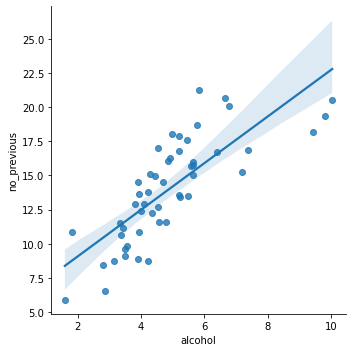

```python
sns.lmplot(data = df,x = "alcohol",y = "no_previous")
```

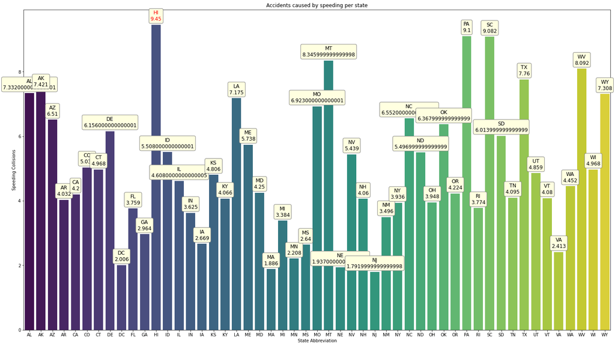

```python
plt.figure(figsize=(25,14))
top_state = df.loc[df['speeding'].idxmax()]
sns.barplot(x="abbrev", y="speeding", data=df, palette="viridis")
for index, row in df.iterrows():
    if row["abbrev"] == top_state["abbrev"]:
        plt.annotate(f'{row["abbrev"]}\n{row["speeding"]}',
                    xy=(index, row["speeding"]),
                    xytext=(0, 10),
                    textcoords='offset points',
                    ha='center',
                    fontsize=12,
                    color='red',
                    bbox=dict(boxstyle='round,pad=0.3', edgecolor='gray', facecolor='lightyellow'))
    else:
        plt.annotate(f'{row["abbrev"]}\n{row["speeding"]}',
                    xy=(index, row["speeding"]),
                    xytext=(0, 10),
                    textcoords='offset points',
                    ha='center',
                    fontsize=12,
                    color='black',
                    bbox=dict(boxstyle='round,pad=0.3', edgecolor='gray', facecolor='lightyellow'))
plt.xlabel("State Abbreviation")
plt.ylabel("Speeding Collisions")
plt.title("Accidents caused by speeding per state")
```

The state of Hawaii has the highest percentage of speeding related car accidents, coming in at 9.45%

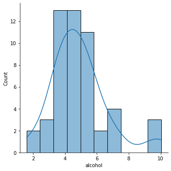

```python
#Seeing data distributions
sns.displot(data=df,x = "alcohol",kde=True)
```

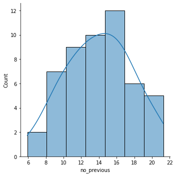

```python
sns.displot(data=df,x = "no_previous",kde=True)
```

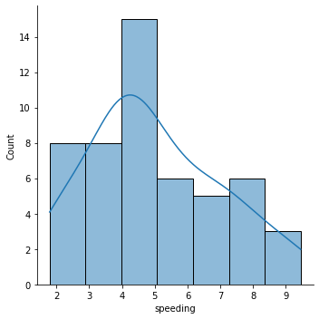

```python
sns.displot(data=df,x="speeding",kde = True)
```

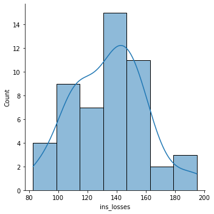

```python
sns.displot(data=df,x="ins_losses",kde = True)
```

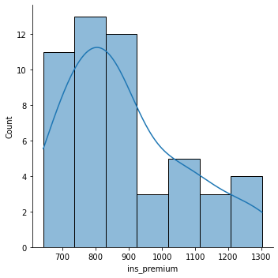

```python
sns.displot(data=df,x="ins_premium",kde=True)
```

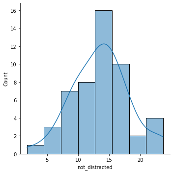

```python
sns.displot(data=df,x="not_distracted",kde=True)
```

It is observed that all the features have a some-what normal distribution curve, most of them being skewed.